# Task 4 — Model Implementation

**Project:** Early Identification of University Students at Risk of Dropping Out  
**Task type:** Supervised multiclass classification  
**Operational score:** Predicted probability of `Dropout`  
**Prediction point:** End of the first semester

The rubric requires experiments with appropriate models, comparison using relevant metrics, and saved configurations and trained artifacts. This notebook compares four classifiers with a non-informative baseline, chooses the best model using training-only cross-validation, tunes the dropout alert threshold with out-of-fold predictions, and evaluates the selected pipeline once on the held-out test partition.

## 1. Evaluation design

The Task 3 split is preserved: 3,539 records for model development and 885 records for final evaluation. No test records participate in preprocessing fitting, feature selection, hyperparameter selection, model selection, or threshold selection.

Five-fold stratified cross-validation compares:

- Dummy prior baseline
- Multinomial Logistic Regression
- Decision Tree
- Random Forest
- Histogram Gradient Boosting

Each real model uses an end-to-end pipeline containing defensive imputation, one-hot encoding, robust scaling, optional training-fold feature selection, and the classifier. The grid tests 30 selected features versus all encoded features. The primary selection metric is dropout F2, which weights recall more heavily than precision. Macro F1, balanced accuracy, accuracy, and multiclass ROC-AUC provide broader checks.

```python
from pathlib import Path
import json
import sys

import pandas as pd
from IPython.display import Image, display

def find_project_root(start: Path) -> Path:
    # Locate the extracted project root from Jupyter's working directory.
    start = start.resolve()
    for candidate in (start, *start.parents):
        if (candidate / "src" / "task4_modeling.py").is_file():
            return candidate
    raise FileNotFoundError(
        "Project root not found. Keep the notebook inside the extracted Task 4 folder."
    )

ROOT = find_project_root(Path.cwd())
if str(ROOT) not in sys.path:
    sys.path.insert(0, str(ROOT))

from src.task4_modeling import run_task4

artifacts = run_task4()
with (ROOT / "reports" / "task4_model_summary.json").open(encoding="utf-8") as handle:
    summary = json.load(handle)

print(f"Training rows: {summary['data']['training_rows']:,}")
print(f"Held-out test rows: {summary['data']['heldout_test_rows']:,}")
print(f"Selected model: {summary['best_model']['name']}")
print(f"Selected dropout threshold: {summary['best_model']['dropout_alert_threshold']:.2f}")
```

```
Training rows: 3,539
Held-out test rows: 885
Selected model: Random Forest
Selected dropout threshold: 0.23
```

## 2. Cross-validated model comparison

Hyperparameters are selected separately for each candidate using the same five stratified folds. The baseline always predicts the most common outcome and demonstrates why raw accuracy is inadequate for this imbalanced problem: it has approximately 50% accuracy while detecting no dropouts.

|  | rank | model | cv_dropout_f2 | cv_dropout_recall | cv_dropout_precision | cv_f1_macro | cv_balanced_accuracy | cv_accuracy | cv_roc_auc_ovr_weighted | best_parameters |
| --- | --- | --- | --- | --- | --- | --- | --- | --- | --- | --- |
| 0 | 1 | Random Forest | 0.756 | 0.746 | 0.802 | 0.683 | 0.677 | 0.749 | 0.885 | {"model__max_features": "sqrt", "model__min_sa... |
| 1 | 2 | Histogram Gradient Boosting | 0.739 | 0.729 | 0.786 | 0.675 | 0.671 | 0.736 | 0.875 | {"model__learning_rate": 0.05, "model__max_lea... |
| 2 | 3 | Logistic Regression | 0.717 | 0.697 | 0.807 | 0.689 | 0.694 | 0.732 | 0.883 | {"model__C": 0.1, "selector__k": "all"} |
| 3 | 4 | Decision Tree | 0.662 | 0.641 | 0.763 | 0.614 | 0.620 | 0.653 | 0.819 | {"model__max_depth": null, "selector__k": 30} |
| 4 | 5 | Dummy Baseline | 0.000 | 0.000 | 0.000 | 0.222 | 0.333 | 0.499 | 0.500 | {"strategy": "prior"} |

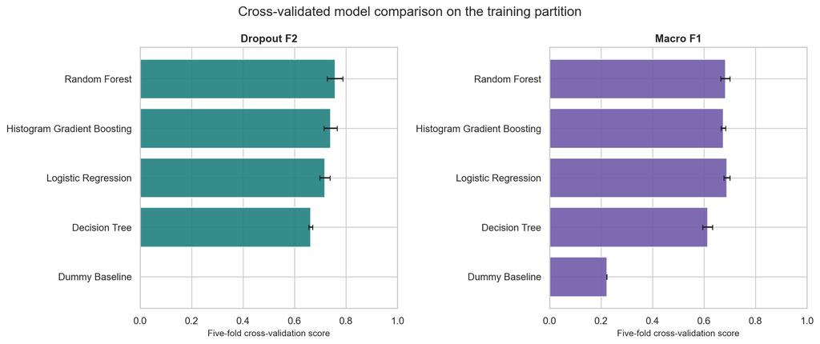

```python
comparison = pd.read_csv(ROOT / "reports" / "tables" / "task4" / "cross_validated_model_comparison.csv")
visible_columns = [
    "rank", "model", "cv_dropout_f2", "cv_dropout_recall",
    "cv_dropout_precision", "cv_f1_macro", "cv_balanced_accuracy",
    "cv_accuracy", "cv_roc_auc_ovr_weighted", "best_parameters"
]
display(comparison[visible_columns].round(3))
display(Image(filename=str(ROOT / "reports" / "figures" / "task4" / "01_cross_validated_model_comparison.png")))
```

### Model choice

Random Forest has the highest cross-validated dropout F2 and satisfies the precision constraint. Its selected configuration uses all encoded features, indicating that the additional weak signals collectively helped more than restricting the model to the 30-feature screening set. This does not invalidate Task 3 feature selection; the 30-feature option was tested fairly and remains useful for sensitivity analysis.

Logistic Regression produces the strongest macro F1 among the candidate point estimates, but the project gives higher priority to identifying future dropouts. Random Forest is therefore chosen using the metric defined before viewing the test set.

```python
best_name = summary["best_model"]["name"]
best_row = comparison.loc[comparison["model"] == best_name].iloc[0]
display(best_row[visible_columns].to_frame("value"))
display(pd.Series(summary["best_model"]["parameters"], name="selected_value").to_frame())
```

|  | value |
| --- | --- |
| rank | 1 |
| model | Random Forest |
| cv_dropout_f2 | 0.756085 |
| cv_dropout_recall | 0.74578 |
| cv_dropout_precision | 0.801561 |
| cv_f1_macro | 0.682555 |
| cv_balanced_accuracy | 0.676974 |
| cv_accuracy | 0.748795 |
| cv_roc_auc_ovr_weighted | 0.88457 |
| best_parameters | {"model__max_features": "sqrt", "model__min_sa... |

|  | selected_value |
| --- | --- |
| model__max_features | sqrt |
| model__min_samples_leaf | 2 |
| selector__k | all |

## 3. Dropout alert threshold

Standard multiclass prediction chooses the class with the largest probability. For early warning, the decision threshold for `Dropout` is tuned separately using only out-of-fold training probabilities. The selected threshold maximizes dropout F2 among thresholds meeting the Task 1 goals of at least 75% dropout recall and 50% dropout precision.

When the dropout probability is below the alert threshold, the prediction is the higher-probability non-dropout class (`Enrolled` or `Graduate`). The saved three-class probabilities remain unchanged.

|  | threshold | dropout_precision | dropout_recall | dropout_f1 | dropout_f2 | macro_f1 | alert_share | selected |
| --- | --- | --- | --- | --- | --- | --- | --- | --- |
| 18 | 0.23 | 0.646 | 0.861 | 0.738 | 0.807 | 0.61 | 0.428 | True |

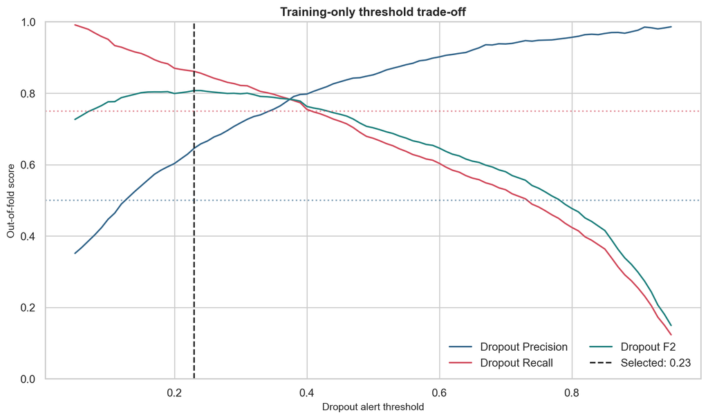

```python
threshold_table = pd.read_csv(ROOT / "reports" / "tables" / "task4" / "oof_threshold_search.csv")
selected_threshold = threshold_table.loc[threshold_table["selected"]]
display(selected_threshold.round(3))
display(Image(filename=str(ROOT / "reports" / "figures" / "task4" / "02_threshold_tradeoff.png")))
```

## 4. Held-out test evaluation

The selected pipeline and threshold are now applied to the 885 test records. Two prediction rules are shown:

- **Default argmax:** better overall multiclass balance.
- **Tuned dropout threshold:** prioritizes early-warning recall and the project’s operational objective.

The tuned rule intentionally trades some accuracy and macro F1 for substantially higher dropout recall. This trade-off should be communicated to decision-makers rather than hidden behind a single aggregate metric.

|  | prediction_rule | accuracy | balanced_accuracy | macro_precision | macro_recall | macro_f1 | weighted_f1 | dropout_precision | dropout_recall | dropout_f1 | dropout_f2 | multiclass_log_loss | roc_auc_ovr_macro | roc_auc_ovr_weighted |
| --- | --- | --- | --- | --- | --- | --- | --- | --- | --- | --- | --- | --- | --- | --- |
| 0 | Default argmax | 0.734 | 0.663 | 0.670 | 0.663 | 0.666 | 0.730 | 0.758 | 0.739 | 0.749 | 0.743 | 0.648 | 0.86 | 0.881 |
| 1 | Dropout threshold 0.23 | 0.704 | 0.602 | 0.601 | 0.602 | 0.583 | 0.679 | 0.626 | 0.838 | 0.717 | 0.785 | 0.648 | 0.86 | 0.881 |

|  | heldout_result |
| --- | --- |
| Dropout recall target met | True |
| Dropout precision floor met | True |
| Top-30% capture target met | True |

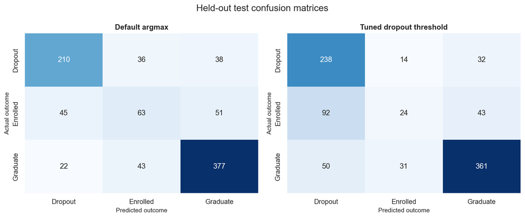

```python
test_metrics = pd.read_csv(ROOT / "reports" / "tables" / "task4" / "heldout_test_metrics.csv")
display(test_metrics.round(3))

success = pd.Series({
    "Dropout recall target met": summary["heldout_test"]["meets_dropout_recall_target"],
    "Dropout precision floor met": summary["heldout_test"]["meets_dropout_precision_floor"],
    "Top-30% capture target met": summary["heldout_test"]["meets_top_30pct_capture_target"],
}, name="heldout_result")
display(success.to_frame())
display(Image(filename=str(ROOT / "reports" / "figures" / "task4" / "03_heldout_confusion_matrices.png")))
```

## 5. Discrimination, capacity, and calibration

ROC and precision-recall curves assess probability ranking across thresholds. The separate top-30% analysis directly measures the Task 1 intervention-list KPI: if support capacity is limited to 30% of students, how many actual dropouts appear in that highest-risk group?

Calibration compares predicted dropout probabilities with observed dropout rates. Good ranking does not automatically guarantee perfectly calibrated probabilities, so later deployment work should monitor and recalibrate probabilities when institutional conditions change.

|  | partition | capacity_share | students_flagged | dropouts_captured | total_dropouts | dropout_capture_rate | precision_at_capacity | lift_at_capacity | baseline_dropout_prevalence |
| --- | --- | --- | --- | --- | --- | --- | --- | --- | --- |
| 0 | Training OOF | 0.3 | 1062 | 853 | 1137 | 0.750 | 0.803 | 2.500 | 0.321 |
| 1 | Held-out test | 0.3 | 266 | 207 | 284 | 0.729 | 0.778 | 2.425 | 0.321 |

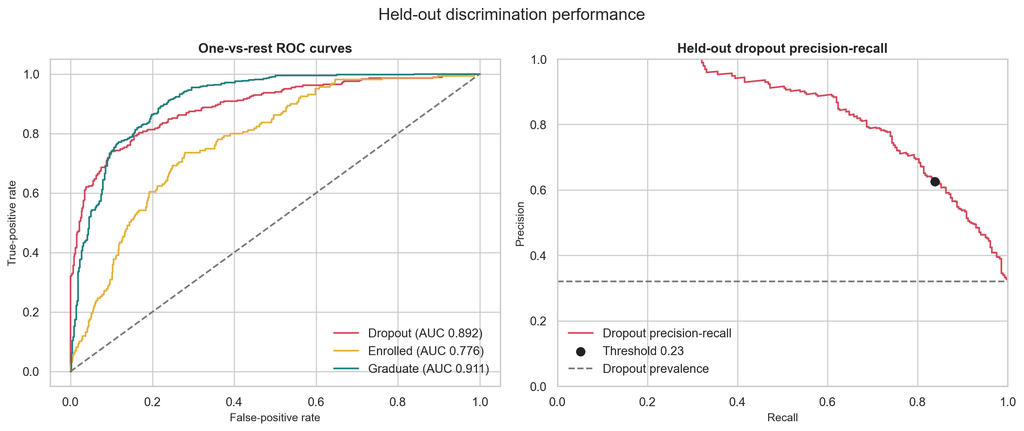

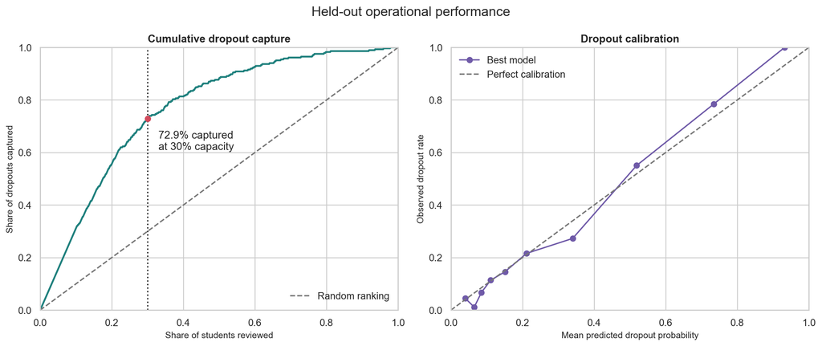

```python
capacity = pd.read_csv(ROOT / "reports" / "tables" / "task4" / "top_30pct_capacity_metrics.csv")
display(capacity.round(3))
display(Image(filename=str(ROOT / "reports" / "figures" / "task4" / "04_heldout_roc_and_precision_recall.png")))
display(Image(filename=str(ROOT / "reports" / "figures" / "task4" / "05_heldout_capacity_and_calibration.png")))
```

## 6. Statistical uncertainty

Point estimates can vary with the test sample. The following percentile intervals use 1,000 bootstrap resamples of the held-out records. They quantify sampling uncertainty within this dataset; they do not address differences between institutions or future policy changes.

```python
intervals = pd.read_csv(ROOT / "reports" / "tables" / "task4" / "test_bootstrap_confidence_intervals.csv")
display(intervals.round(3))
```

|  | metric | bootstrap_mean | ci_95_lower | ci_95_upper | iterations |
| --- | --- | --- | --- | --- | --- |
| 0 | dropout_precision | 0.625 | 0.578 | 0.673 | 1000 |
| 1 | dropout_recall | 0.837 | 0.792 | 0.881 | 1000 |
| 2 | dropout_f2 | 0.783 | 0.746 | 0.820 | 1000 |
| 3 | macro_f1 | 0.583 | 0.552 | 0.615 | 1000 |

## 7. Results and decision

The final Random Forest uses a dropout threshold of 0.23. On the held-out test set it achieves:

- **Dropout recall:** 83.8%
- **Dropout precision:** 62.6%
- **Dropout F2:** 78.5%
- **Multiclass one-vs-rest ROC-AUC:** 86.0% macro and 88.1% weighted
- **Top-30% capture:** 72.9% of actual dropouts (207 of 284)
- **Precision in the top-risk group:** 77.8%, or 2.43 times the underlying dropout prevalence

All three Task 1 success thresholds are met on the held-out data. However, the alert threshold flags approximately 42.8% of out-of-fold training students, while the top-30% list represents a capacity-constrained intervention policy. These are separate operating choices: one is a probability threshold; the other is a fixed support capacity.

Fairness, subgroup error rates, and model-explanation checks remain mandatory before any deployment decision and are addressed in Task 5.

## 8. Reproducibility artifacts

- `models/task4/`: every fitted candidate pipeline and the final model bundle
- `configs/task4_model_config.json`: random seed, cross-validation, parameter grids, chosen parameters, threshold, and input columns
- `reports/tables/task4/`: comparison, threshold, held-out metrics, predictions, and confidence intervals
- `reports/figures/task4/`: model-comparison and evaluation figures
- `reports/task4_model_summary.json`: machine-readable headline results

The final bundle stores the complete preprocessing and model pipeline together with its class order, input columns, alert threshold, and prediction rule.